# take home midterm 2

```r
library(runjags)
```

```r
library(coda)
library(ggplot2)
library(tidyverse)
library(ggridges)
setwd("C:/Users/Gorge-PC/Documents")

animation_data <- read.csv("2010_animation_ratings.csv")
house_data<- read.csv("house_prices.csv")
```

1. A normal distributon should fit the data well. As for priors, each prior has a different mean, so we should give each movie index its own prior, but they can share a standard deviation. Each mean would be given by a truncated normal distribution, because ratings can’t be negative, where mean = mu and precision = tau. Mu and tau are assigned priors. Mu would be drawn from a truncated normal distrbution with mean = a and standard deviation = b. Tau would be drawn from a gamma distribution with alpha = c and beta = d. a, b, c, and d are fixed values.

Sigma is also assigned a vague prior which would be a gamma distribution with alpha = e and beta = f.

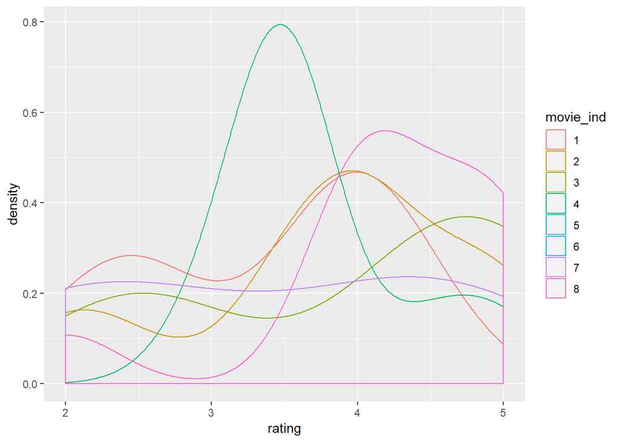

```r
movie_ind<-as.factor(animation_data$Group_Number)
rating<- animation_data$rating
N<- length(rating)
num_groups<- length(unique(animation_data$Group_Number))


ggplot(data= data.frame(movie_ind= movie_ind, rating = rating), aes(rating, color= movie_ind)) + geom_density()
```

```r
modelString <-"


model {

## likelihood
for (i in 1:N){
rating[i] ~ dnorm(mu_group[movie_ind[i]], precision)T(0,)
}

## priors
for (j in 1:num_groups){
mu_group[j] ~ dnorm(mu, inv_tau)T(0,)
}
precision ~ dgamma(e, f)
sigma <- sqrt(pow(precision, -1))

## hyperpriors
mu ~ dnorm(a, b)T(0,)
inv_tau ~ dgamma(c, d)
tau <- sqrt(pow(inv_tau, -1))

}
"


model_data <- list("rating" = rating, "movie_ind" = movie_ind, "N" = N, "num_groups" = num_groups,"a" = 0, "b" = 0.001,  "e" = 1, "f" = 1, "c" = 1, "d" = 1)

posterior <- run.jags(modelString,
                      n.chains = 1,
                      data = model_data,
                      monitor = c("mu", "tau", "mu_group", "sigma"),
                      adapt = 1000,
                      burnin = 5000,
                      sample = 5000,
                      thin = 1)
```

```
## Calling the simulation...
## Welcome to JAGS 4.3.0 on Wed May 01 09:34:19 2019
## JAGS is free software and comes with ABSOLUTELY NO WARRANTY
## Loading module: basemod: ok
## Loading module: bugs: ok
## . . Reading data file data.txt
## . Compiling model graph
## . Initializing model
## . Adapting 1000
## -------------------------------------------------| 1000
## ++++++++++++++++++++++++++++++++++++++++++++++++++ 100%
## Adaptation successful
## . Updating 5000
## -------------------------------------------------| 5000
## ************************************************** 100%
## . . . . . Updating 5000
## -------------------------------------------------| 5000
## ************************************************** 100%
## . . . . Updating 0
## . Deleting model
## .
## Simulation complete.  Reading coda files...
## Coda files loaded successfully
## Calculating summary statistics...
```

```
## Finished running the simulation
```

```r
summary(posterior)
```

```
##              Lower95    Median Upper95      Mean         SD Mode
## mu          3.207200 3.8476550 4.43963 3.8455995 0.31437277   NA
## tau         0.348273 0.6434020 1.08052 0.6848237 0.21357821   NA
## mu_group[1] 2.983680 3.4747600 4.01474 3.4792670 0.26466820   NA
## mu_group[2] 3.376680 3.8134250 4.25316 3.8126378 0.22349936   NA
## mu_group[3] 3.086220 3.9222700 4.78000 3.9260011 0.42915039   NA
## mu_group[4] 3.165470 3.7442450 4.29043 3.7480193 0.28859440   NA
## mu_group[5] 3.145620 4.2377750 5.42639 4.2390431 0.58769126   NA
## mu_group[6] 2.717220 3.8797400 5.00833 3.8865713 0.58047018   NA
## mu_group[7] 2.786440 3.5449350 4.30850 3.5405101 0.39251307   NA
## mu_group[8] 3.615040 4.1347100 4.65969 4.1396858 0.26888672   NA
## sigma       0.749356 0.9218865 1.10610 0.9299254 0.09274924   NA
##                   MCerr MC%ofSD SSeff        AC.10 psrf
## mu          0.007980200     2.5  1552 -0.019995911   NA
## tau         0.005286090     2.5  1632 -0.001093303   NA
## mu_group[1] 0.005156863     1.9  2634  0.018228980   NA
## mu_group[2] 0.004275024     1.9  2733 -0.014471835   NA
## mu_group[3] 0.008592183     2.0  2495 -0.035197156   NA
## mu_group[4] 0.005224126     1.8  3052  0.021280034   NA
## mu_group[5] 0.013400136     2.3  1923 -0.012556797   NA
## mu_group[6] 0.012818832     2.2  2051  0.022957824   NA
## mu_group[7] 0.007678952     2.0  2613 -0.005972225   NA
## mu_group[8] 0.004829604     1.8  3100  0.015567790   NA
## sigma       0.001830684     2.0  2567  0.019980406   NA
```

```
## Generating plots...
```

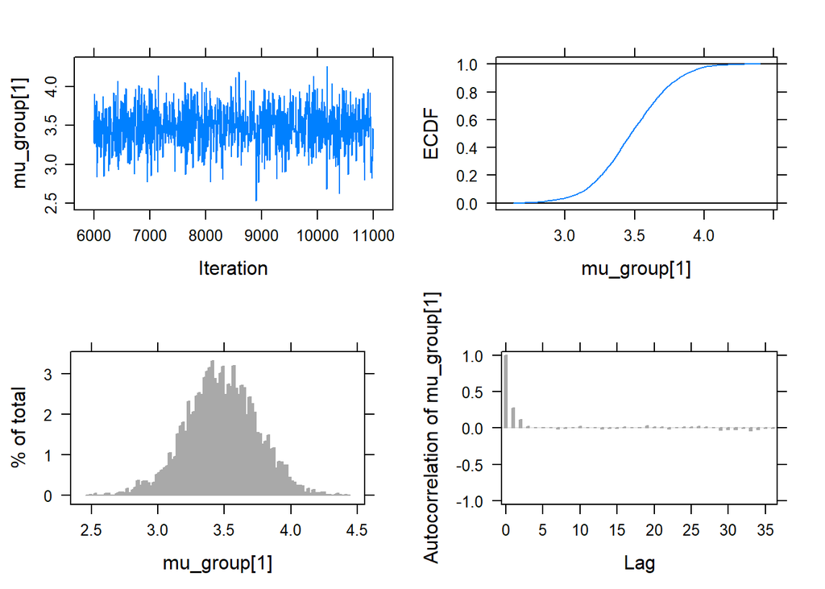

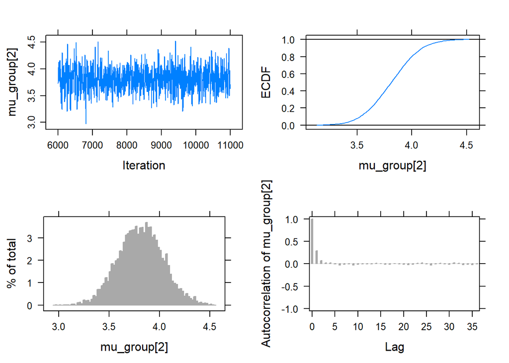

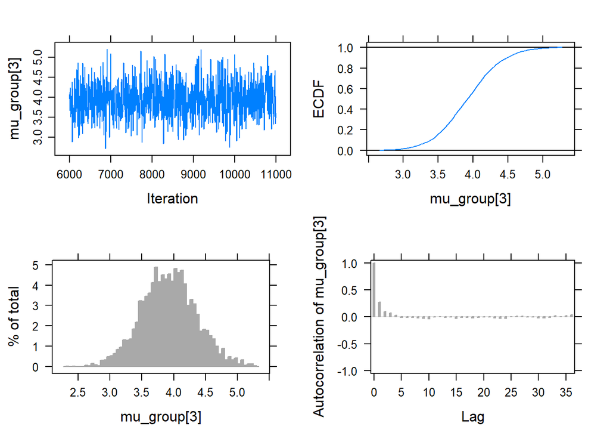

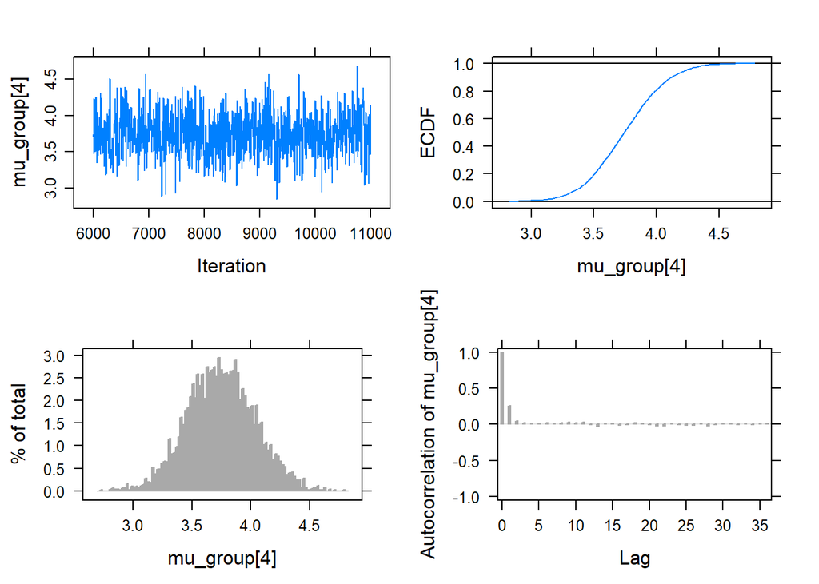

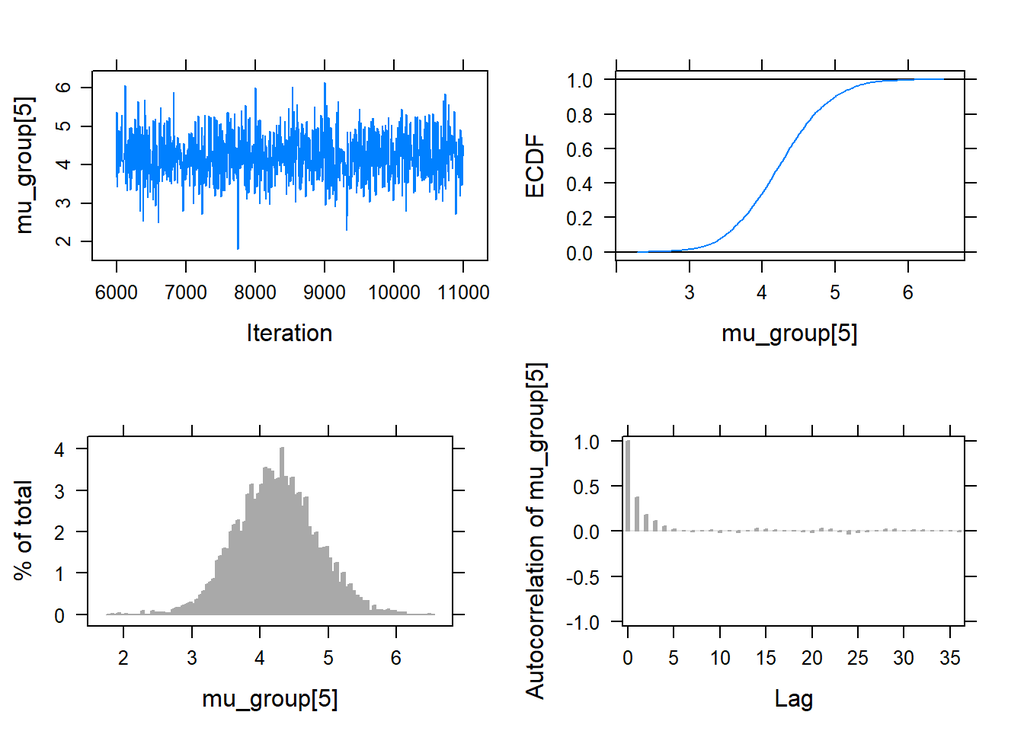

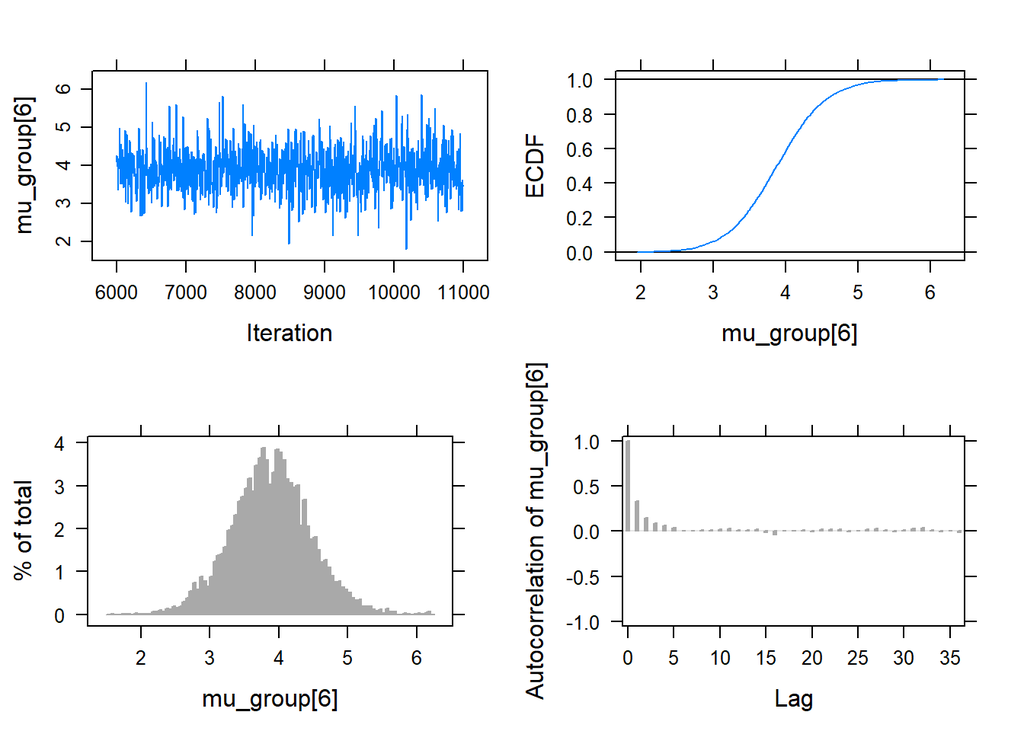

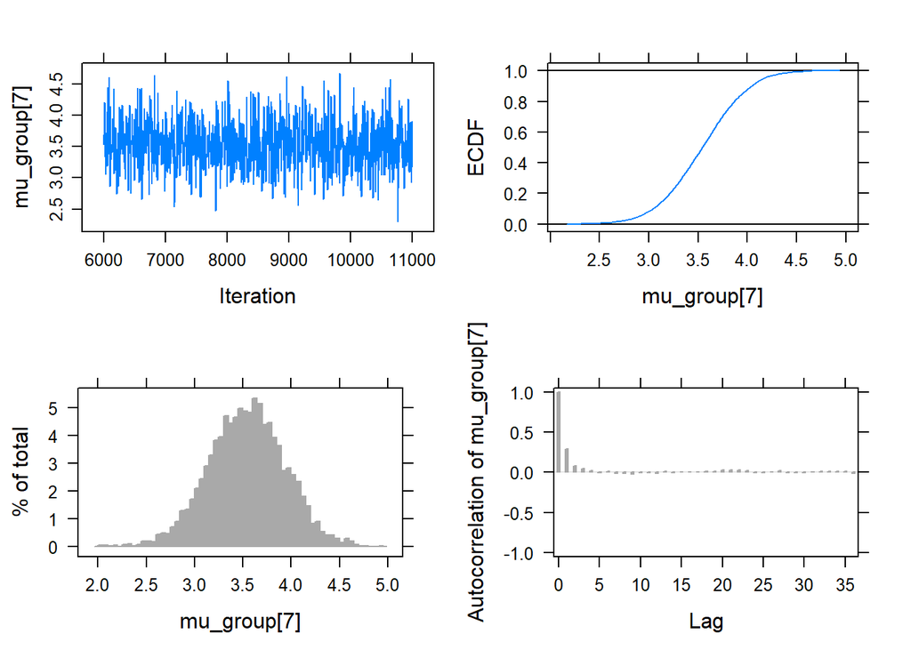

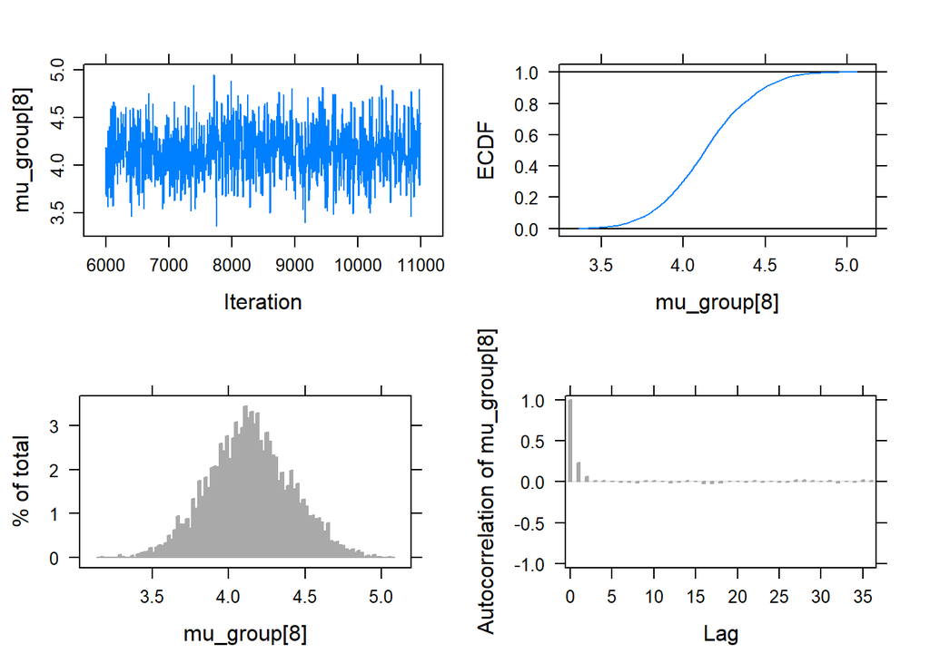

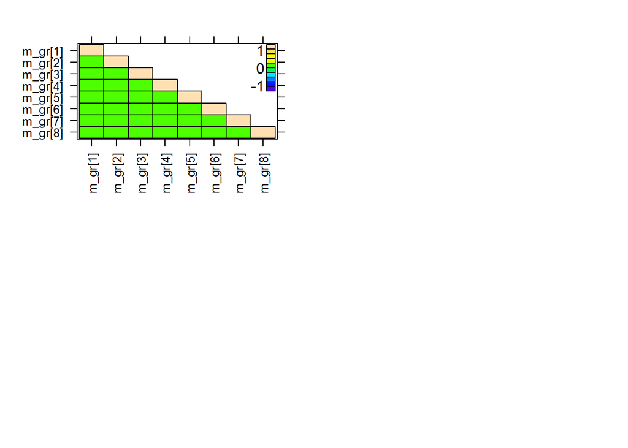

```r
plot(posterior, vars = "mu_group")
```

```
## Generating plots...
```

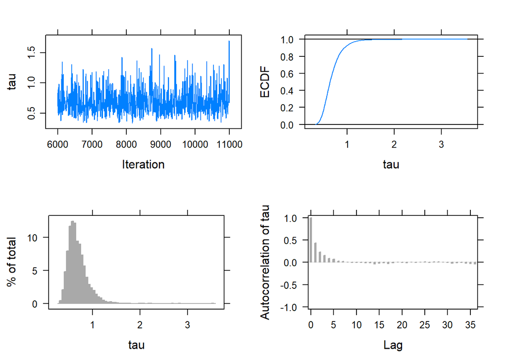

```r
plot(posterior, vars = "tau")
```

```
## Generating plots...
```

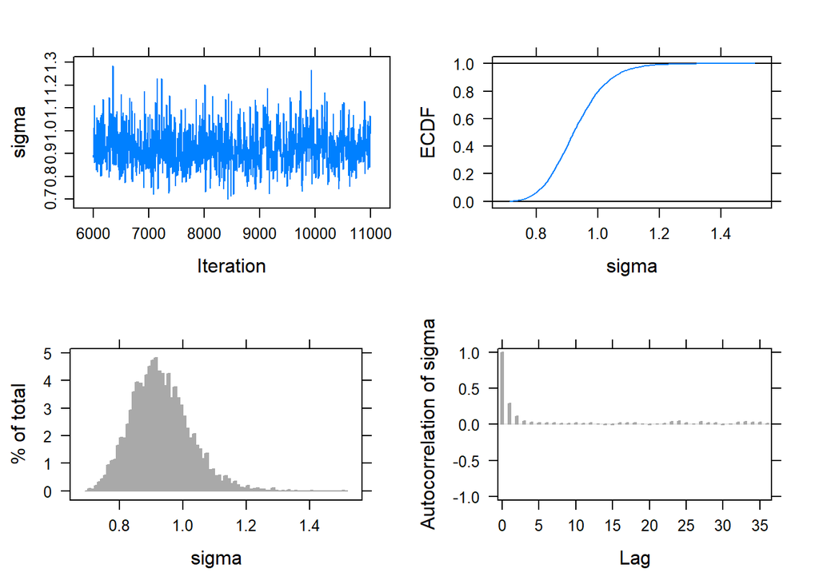

```r
plot(posterior, vars = "sigma")
```

2. MCMC diagonstics don’t show many problems. A lot of the variables have relatively small autocorellations and all of the traceplots look like they explore the full parameter space. mu_group[5] has one of the larger autocorrelations out of them. Even then, autocorrelation is still close to 0 after a little bit.

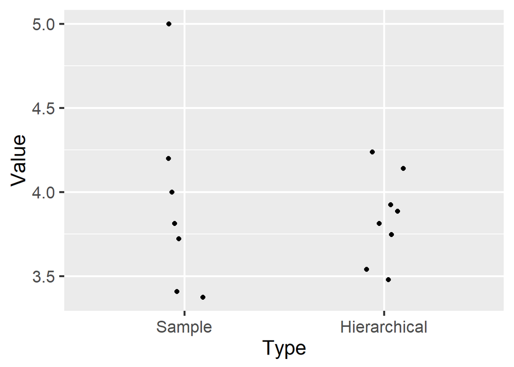

```r
Ind_Stats = as.data.frame(matrix(NA, num_groups, 2))
names(Ind_Stats) = c("mean", "sd")
for (j in 1:num_groups){
Ind_Stats[j, ] = c(mean(animation_data$rating[animation_data$Group_Number == j]),
sd(animation_data$rating[animation_data$Group_Number == j]))
}
Post_Means <- summary(posterior)[, 4]
Means1 <- data.frame(Type = "Sample", Value = Ind_Stats$mean)
Means2 <- data.frame(Type = "Hierarchical", Value =
Post_Means[3:(4 + num_groups - 2)])
ggplot(rbind(Means1, Means2), aes(Type, Value)) +
geom_jitter(width = 0.1, size = 2)+
theme_grey(base_size = 20, base_family = "")
```

Complete-pooling refers to when all of the priors come from the same normal distribution. Zero pooling refers to when all of the priors come from different normal distributions. In this case there is partial pooling. Because they share a sigma there is some pooling, but the means came from different distributions so there wasn’t complete pooling. The means are much closer together in our hierarchical model compared to the sample.

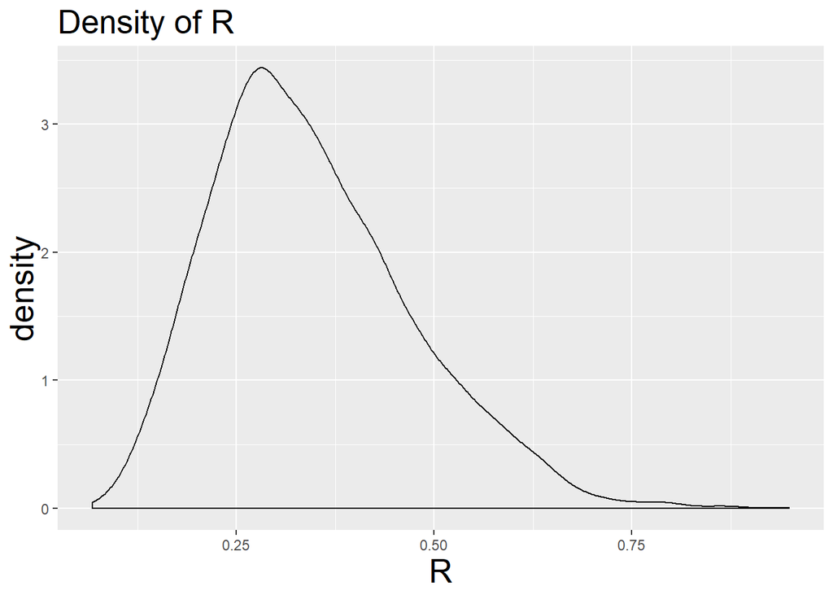

```r
tau_draws <- as.mcmc(posterior,
vars = "tau")
sigma_draws <- as.mcmc(posterior,
vars = "sigma")
R = tau_draws^2/(tau_draws^2 + sigma_draws^2)
df = as.data.frame(R)
ggplot(df, aes(x=R)) + geom_density() + labs(title="Density of R") +
theme(plot.title = element_text(size=20)) +
theme(axis.title = element_text(size=20))
```

```r
quantile(R, c(0.025, 0.975))
```

```
##      2.5%     97.5%
## 0.1463909 0.6281329
```

```r
modelString <-"
model {
## sampling
for (i in 1:N){
y[i] ~ dnorm(beta0 + beta1*size[i], precision)
}
## priors
beta0 ~ dnorm(mu0, g0)
beta1 ~ dnorm(mu1, g1)
precision ~ dgamma(a, b)
sigma <- sqrt(pow(precision, -1))
}
"

y = house_data$price
size = house_data$size
N = length(y)

the_data <- list("y" = y, "size" = size, "N" = N,
                 "mu0" = 0, "g0" = 0.0001,
                 "mu1" = 0, "g1" = 0.0001,
                 "a" = 1, "b" = 1)


posterior <- run.jags(modelString,
                      n.chains = 1,
                      data = the_data,
                      monitor = c("beta0", "beta1", "sigma"),
                      adapt = 1000,
                      thin = 25,
                      burnin = 5000,
                      sample = 5000)
```

```
## Calling the simulation...
## Welcome to JAGS 4.3.0 on Wed May 01 09:34:36 2019
## JAGS is free software and comes with ABSOLUTELY NO WARRANTY
## Loading module: basemod: ok
## Loading module: bugs: ok
## . . Reading data file data.txt
## . Compiling model graph
## . Initializing model
## . Adaptation skipped: model is not in adaptive mode.
## . Updating 5000
## -------------------------------------------------| 5000
## ************************************************** 100%
## . . . . Updating 125000
## -------------------------------------------------| 125000
## ************************************************** 100%
## . . . . Updating 0
## . Deleting model
## .
## Note: the model did not require adaptation
## Simulation complete.  Reading coda files...
## Coda files loaded successfully
## Calculating summary statistics...
```

```
## Finished running the simulation
```

```r
summary(posterior)
```

```
##           Lower95     Median   Upper95        Mean         SD Mode
## beta0 -126.163000 -52.325500 16.326800 -52.4489329 36.2861801   NA
## beta1    0.083438   0.121067  0.159478   0.1209378  0.0192643   NA
## sigma   32.929200  44.720800 59.172500  45.5100317  7.0437681   NA
##              MCerr MC%ofSD SSeff      AC.250 psrf
## beta0 0.6008600334     1.7  3647  0.02777921   NA
## beta1 0.0003214292     1.7  3592  0.01083830   NA
## sigma 0.1061438607     1.5  4404 -0.01428170   NA
```

```
## Generating plots...
```

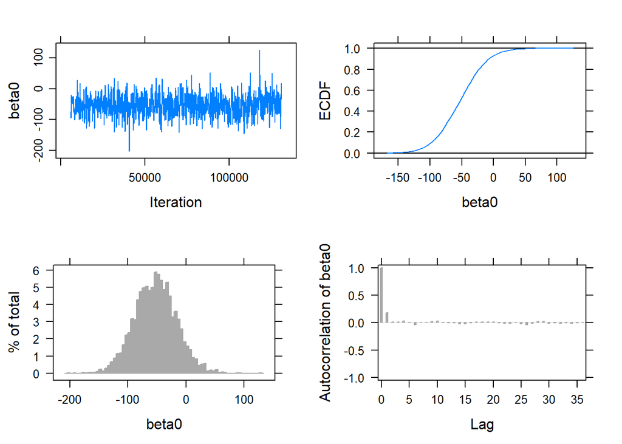

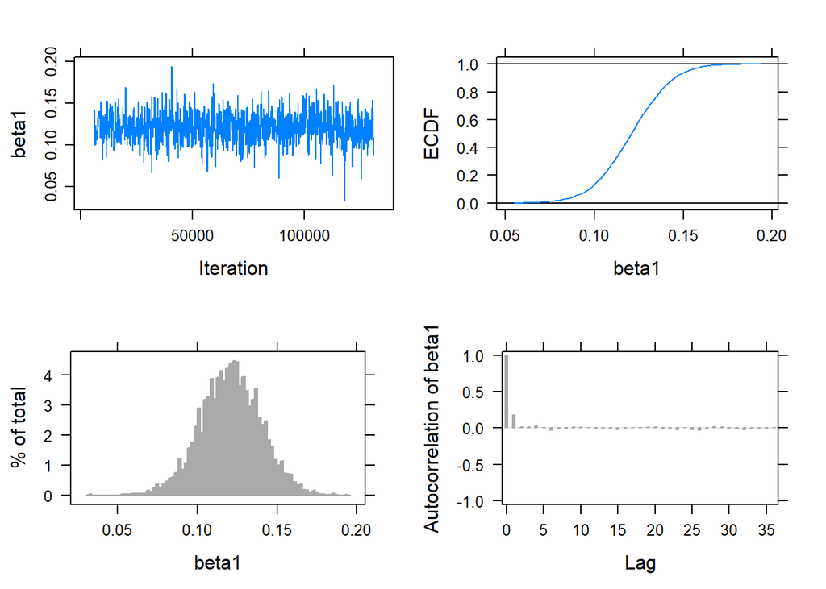

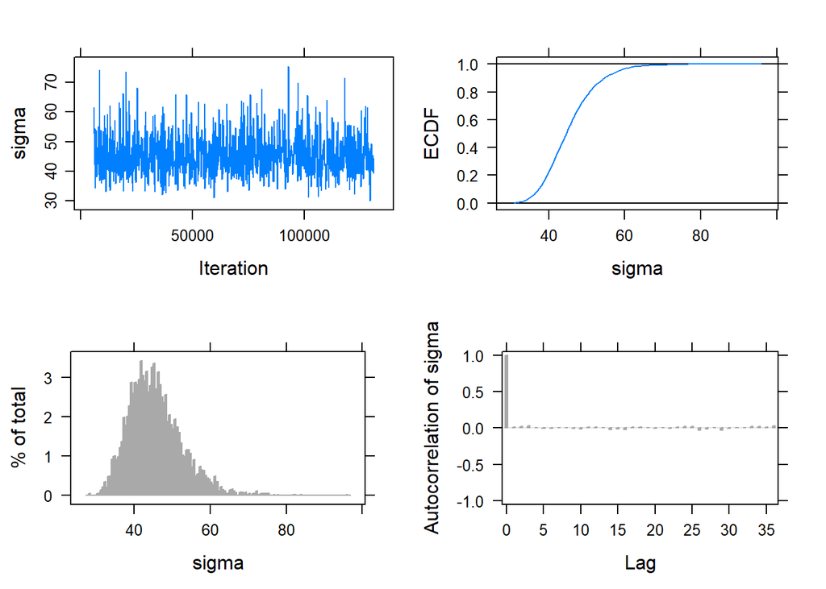

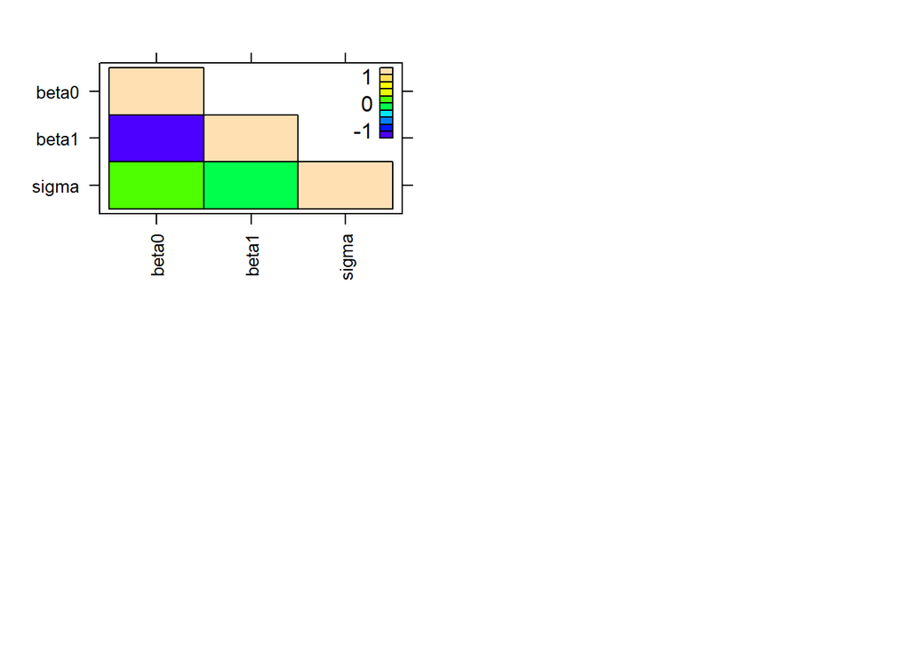

```r
plot(posterior, vars = c('beta0','beta1','sigma'))
```

MCMC diagnostics show relatively good results. Autocorrelation was really high at first, especially with beta0 and beta1. After setting thinning to 25, the auto correlations are much lower. The traceplots look like they fully explore the parameter space. Overall, after increasing thinning, it seems to have converged and looks pretty good otherwise.

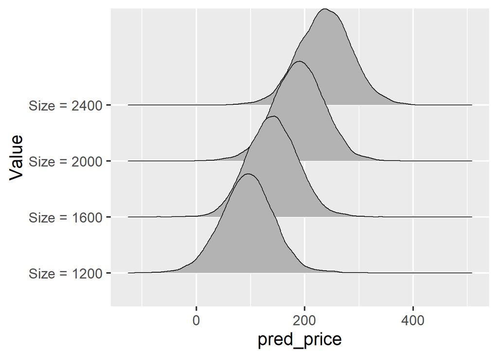

```r
post = as.mcmc(posterior)
post_means = apply(post, 2, mean)
posterior = as.data.frame(post)

one_predicted <- function(x){
lp <- posterior[ , "beta0"] + x * posterior[ , "beta1"]
y <- rnorm(5000, lp, posterior[, "sigma"])
data.frame(Value = paste("Size =", x),
pred_price = y)
}
df <- map_df(c(1200, 1600, 2000, 2400), one_predicted)
ggplot(df, aes(x = pred_price, y = Value)) +
geom_density_ridges() +
theme_grey(base_size = 18, base_family = "")
```

```r
df %>% group_by(Value) %>%
summarize(P05 = quantile(pred_price, 0.05),
P50 = median(pred_price),
P95 = quantile(pred_price, 0.95), mean = mean(pred_price))
```

```
## # A tibble: 4 x 5
##   Value         P05   P50   P95  mean
##   <chr>       <dbl> <dbl> <dbl> <dbl>
## 1 Size = 1200  14.0  94.5  173.  93.9
## 2 Size = 1600  65.9 140.   216. 141.
## 3 Size = 2000 112.  190.   267. 189.
## 4 Size = 2400 157.  238.   317. 237.
```